DATASET ACTIVATE DataSet2.  
SAVE OUTFILE='Z:\Documents\GitHub\STISIM-Task-Analysis\SPSS Results\Saccade_peakV_20-30.sav'  
/COMPRESSED.  
DATASET ACTIVATE DataSet1.  
DATASET CLOSE DataSet2.  
GET  
FILE='Z:\Documents\GitHub\STISIM-Task-Analysis\SPSS Results\Saccade_peakV_30-40.sav'.  
DATASET NAME DataSet3 WINDOW=FRONT.  
* Encoding: UTF-8.  
EXAMINE VARIABLES=S1_R1 S1_R2 S2_R1 S2_R2  
/PLOT BOXPLOT NPPLOT  
/COMPARE GROUPS  
/STATISTICS NONE  
/CINTERVAL 95  
/MISSING LISTWISE  
/NOTOTAL.

# **Explore**

NotesNotes, table, 0 levels of column headers and 2 levels of row headers, table with 3 columns and 14 rows

| Output Created |  | 16-APR-2019 00:48:22 |
| --- | --- | --- |
| Comments |  |  |
| Input | Data | Z:\Documents\GitHub\STISIM-Task-Analysis\SPSS Results\Saccade_peakV_30-40.sav |
|  | Active Dataset | DataSet3 |
|  | Filter | <none> |
|  | Weight | <none> |
|  | Split File | <none> |
|  | N of Rows in Working Data File | 13 |
| Missing Value Handling | Definition of Missing | User-defined missing values for dependent variables are treated as missing. |
|  | Cases Used | Statistics are based on cases with no missing values for any dependent variable or factor used. |
| Syntax |  | EXAMINE VARIABLES=S1_R1 S1_R2 S2_R1 S2_R2 /PLOT BOXPLOT NPPLOT /COMPARE GROUPS /STATISTICS NONE /CINTERVAL 95 /MISSING LISTWISE /NOTOTAL. |
| Resources | Processor Time | 00:00:02.50 |
|  | Elapsed Time | 00:00:02.26 |

[DataSet3] Z:\Documents\GitHub\STISIM-Task-Analysis\SPSS Results\Saccade_peakV_30-40.sav

Case Processing SummaryCase Processing Summary, table, 3 levels of column headers and 1 levels of row headers, table with 7 columns and 8 rows

|  | Cases |  |  |  |  |  |
| --- | --- | --- | --- | --- | --- | --- |
|  | Valid |  | Missing |  | Total |  |
|  | N | Percent | N | Percent | N | Percent |
| S1_R1 | 9 | 69.2% | 4 | 30.8% | 13 | 100.0% |
| S1_R2 | 9 | 69.2% | 4 | 30.8% | 13 | 100.0% |
| S2_R1 | 9 | 69.2% | 4 | 30.8% | 13 | 100.0% |
| S2_R2 | 9 | 69.2% | 4 | 30.8% | 13 | 100.0% |

Tests of NormalityTests of Normality, table, 2 levels of column headers and 1 levels of row headers, table with 7 columns and 9 rows

|  | Kolmogorov-Smirnov<sup>a</sup> |  |  | Shapiro-Wilk |  |  |
| --- | --- | --- | --- | --- | --- | --- |
|  | Statistic | df | Sig. | Statistic | df | Sig. |
| S1_R1 | .158 | 9 | .200* | .948 | 9 | .665 |
| S1_R2 | .142 | 9 | .200* | .972 | 9 | .908 |
| S2_R1 | .152 | 9 | .200* | .959 | 9 | .785 |
| S2_R2 | .134 | 9 | .200* | .974 | 9 | .928 |

*. This is a lower bound of the true significance.  
a. Lilliefors Significance Correction

# **S1_R1**

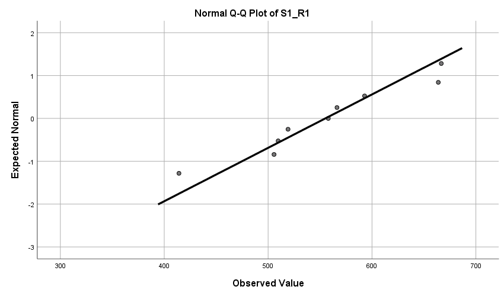

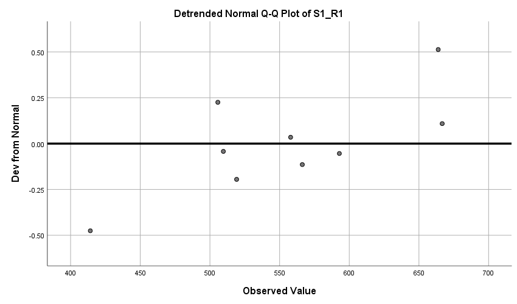

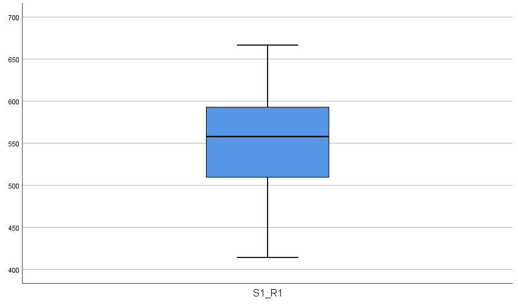

# **S1_R2**

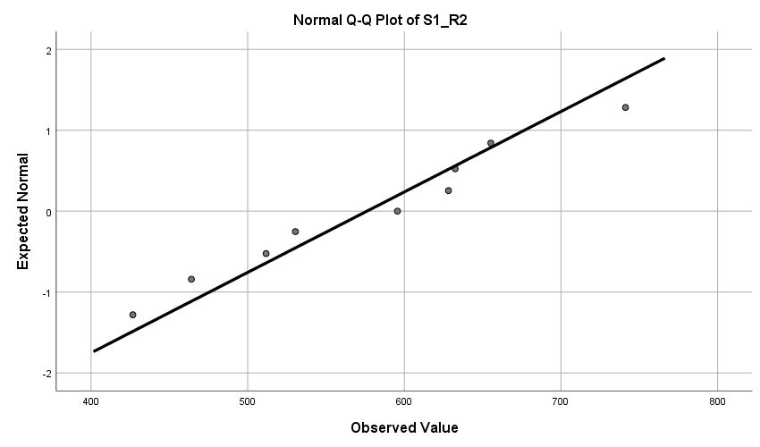

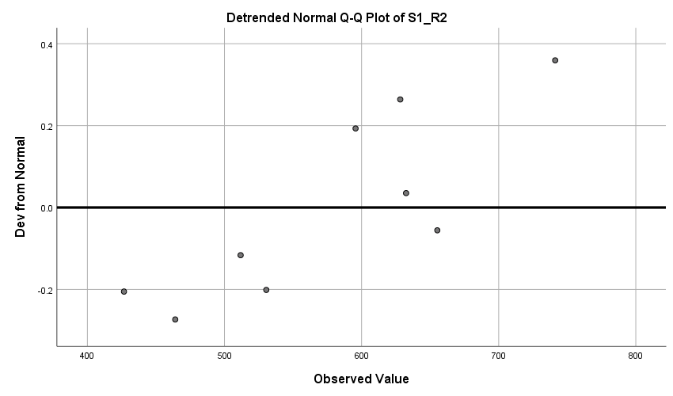

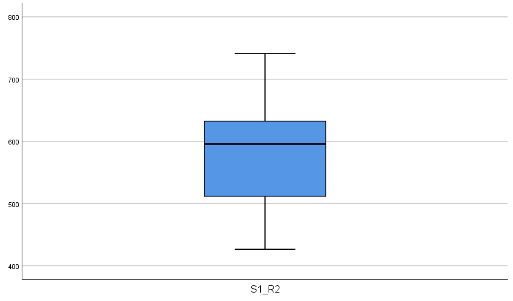

# **S2_R1**

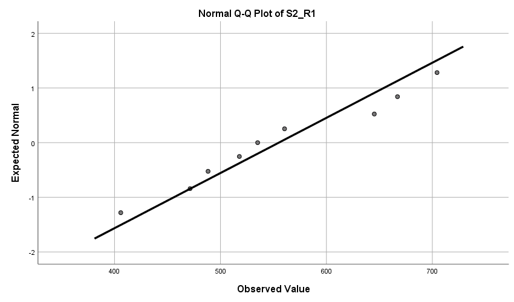

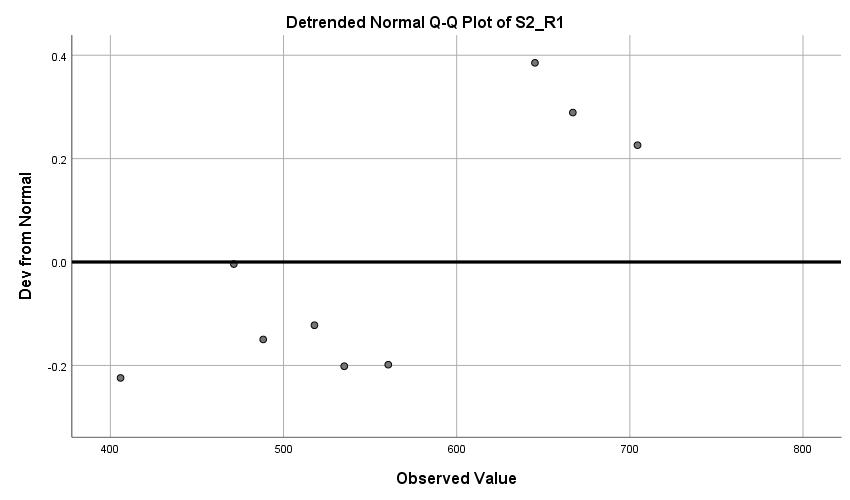

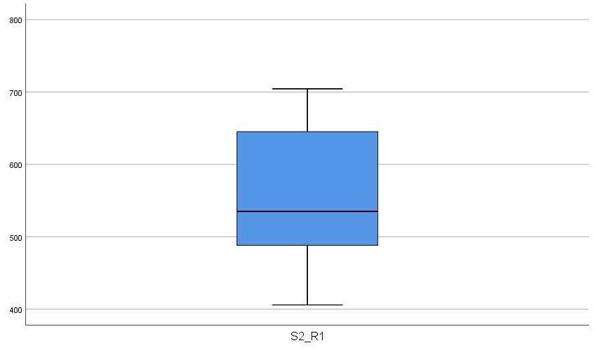

# **S2_R2**

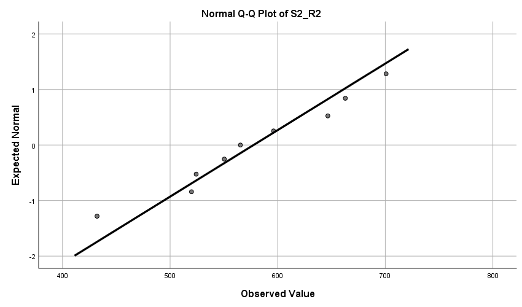

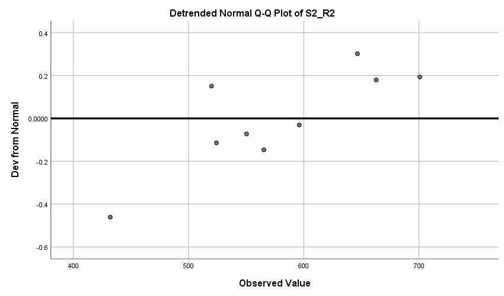

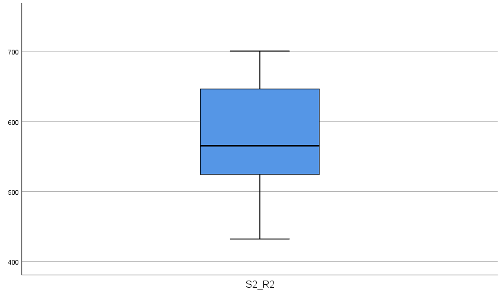

T-TEST PAIRS=S1_R1 S2_R1 S1_R2 WITH S1_R2 S2_R2 S2_R2 (PAIRED)  
/CRITERIA=CI(.9500)  
/MISSING=ANALYSIS.

# **T-Test**

NotesNotes, table, 0 levels of column headers and 2 levels of row headers, table with 3 columns and 14 rows

| Output Created |  | 16-APR-2019 00:48:24 |
| --- | --- | --- |
| Comments |  |  |
| Input | Data | Z:\Documents\GitHub\STISIM-Task-Analysis\SPSS Results\Saccade_peakV_30-40.sav |
|  | Active Dataset | DataSet3 |
|  | Filter | <none> |
|  | Weight | <none> |
|  | Split File | <none> |
|  | N of Rows in Working Data File | 13 |
| Missing Value Handling | Definition of Missing | User defined missing values are treated as missing. |
|  | Cases Used | Statistics for each analysis are based on the cases with no missing or out-of-range data for any variable in the analysis. |
| Syntax |  | T-TEST PAIRS=S1_R1 S2_R1 S1_R2 WITH S1_R2 S2_R2 S2_R2 (PAIRED) /CRITERIA=CI(.9500) /MISSING=ANALYSIS. |
| Resources | Processor Time | 00:00:00.02 |
|  | Elapsed Time | 00:00:00.04 |

Paired Samples StatisticsPaired Samples Statistics, table, 1 levels of column headers and 2 levels of row headers, table with 6 columns and 8 rows

|  |  | Mean | N | Std. Deviation | Std. Error Mean |
| --- | --- | --- | --- | --- | --- |
| Pair 1 | S1_R1 | 558.927273 | 11 | 75.7834655 | 22.8495746 |
|  | S1_R2 | 587.891818 | 11 | 94.6527726 | 28.5388847 |
| Pair 2 | S2_R1 | 548.066364 | 11 | 99.3464922 | 29.9540944 |
|  | S2_R2 | 561.691818 | 11 | 91.5139149 | 27.5924835 |
| Pair 3 | S1_R2 | 575.664545 | 11 | 112.5947404 | 33.9485916 |
|  | S2_R2 | 561.691818 | 11 | 91.5139149 | 27.5924835 |

Paired Samples CorrelationsPaired Samples Correlations, table, 1 levels of column headers and 2 levels of row headers, table with 5 columns and 5 rows

|  |  | N | Correlation | Sig. |
| --- | --- | --- | --- | --- |
| Pair 1 | S1_R1 & S1_R2 | 11 | .530 | .094 |
| Pair 2 | S2_R1 & S2_R2 | 11 | .758 | .007 |
| Pair 3 | S1_R2 & S2_R2 | 11 | .824 | .002 |

Paired Samples TestPaired Samples Test, table, 3 levels of column headers and 2 levels of row headers, table with 10 columns and 7 rows

[output not shown]

COMPUTE logS1_R1=LG10(S1_R1).  
EXECUTE.  
COMPUTE logS1_R2=LG10(S1_R2).  
EXECUTE.  
COMPUTE logS2_R1=LG10(S2_R1).  
EXECUTE.  
COMPUTE logS2_R2=LG10(S2_R2).  
EXECUTE.  
EXAMINE VARIABLES=logS1_R1 logS1_R2 logS2_R1 logS2_R2  
/PLOT NPPLOT  
/STATISTICS NONE  
/CINTERVAL 95  
/MISSING LISTWISE  
/NOTOTAL.

# **Explore**

NotesNotes, table, 0 levels of column headers and 2 levels of row headers, table with 3 columns and 14 rows

| Output Created |  | 16-APR-2019 00:48:25 |
| --- | --- | --- |
| Comments |  |  |
| Input | Data | Z:\Documents\GitHub\STISIM-Task-Analysis\SPSS Results\Saccade_peakV_30-40.sav |
|  | Active Dataset | DataSet3 |
|  | Filter | <none> |
|  | Weight | <none> |
|  | Split File | <none> |
|  | N of Rows in Working Data File | 13 |
| Missing Value Handling | Definition of Missing | User-defined missing values for dependent variables are treated as missing. |
|  | Cases Used | Statistics are based on cases with no missing values for any dependent variable or factor used. |
| Syntax |  | EXAMINE VARIABLES=logS1_R1 logS1_R2 logS2_R1 logS2_R2 /PLOT NPPLOT /STATISTICS NONE /CINTERVAL 95 /MISSING LISTWISE /NOTOTAL. |
| Resources | Processor Time | 00:00:01.64 |
|  | Elapsed Time | 00:00:01.47 |

Case Processing SummaryCase Processing Summary, table, 3 levels of column headers and 1 levels of row headers, table with 7 columns and 8 rows

|  | Cases |  |  |  |  |  |
| --- | --- | --- | --- | --- | --- | --- |
|  | Valid |  | Missing |  | Total |  |
|  | N | Percent | N | Percent | N | Percent |
| logS1_R1 | 9 | 69.2% | 4 | 30.8% | 13 | 100.0% |
| logS1_R2 | 9 | 69.2% | 4 | 30.8% | 13 | 100.0% |
| logS2_R1 | 9 | 69.2% | 4 | 30.8% | 13 | 100.0% |
| logS2_R2 | 9 | 69.2% | 4 | 30.8% | 13 | 100.0% |

Tests of NormalityTests of Normality, table, 2 levels of column headers and 1 levels of row headers, table with 7 columns and 9 rows

|  | Kolmogorov-Smirnov<sup>a</sup> |  |  | Shapiro-Wilk |  |  |
| --- | --- | --- | --- | --- | --- | --- |
|  | Statistic | df | Sig. | Statistic | df | Sig. |
| logS1_R1 | .175 | 9 | .200* | .941 | 9 | .595 |
| logS1_R2 | .160 | 9 | .200* | .967 | 9 | .866 |
| logS2_R1 | .153 | 9 | .200* | .966 | 9 | .856 |
| logS2_R2 | .149 | 9 | .200* | .963 | 9 | .831 |

*. This is a lower bound of the true significance.  
a. Lilliefors Significance Correction

# **logS1_R1**

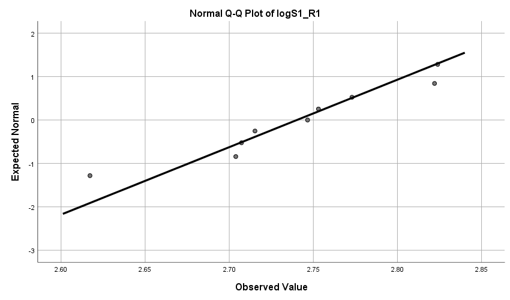

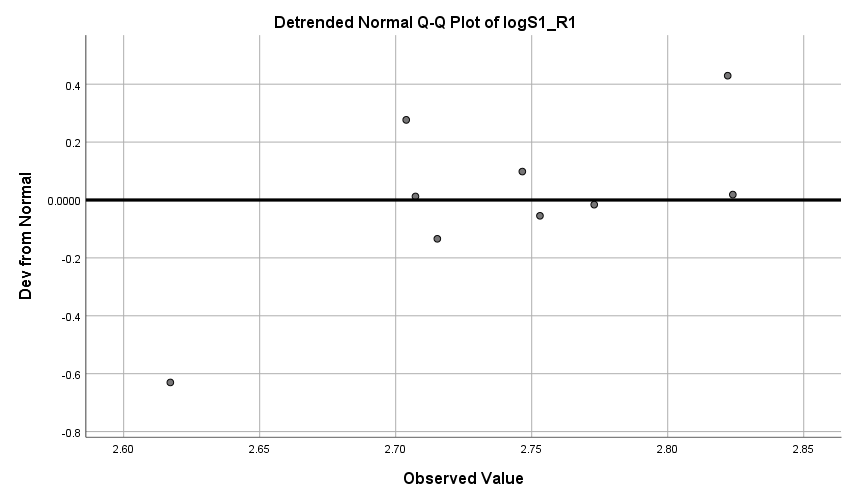

# **logS1_R2**

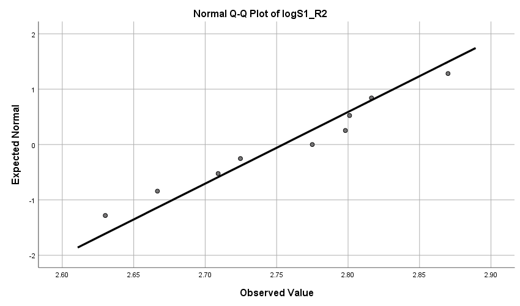

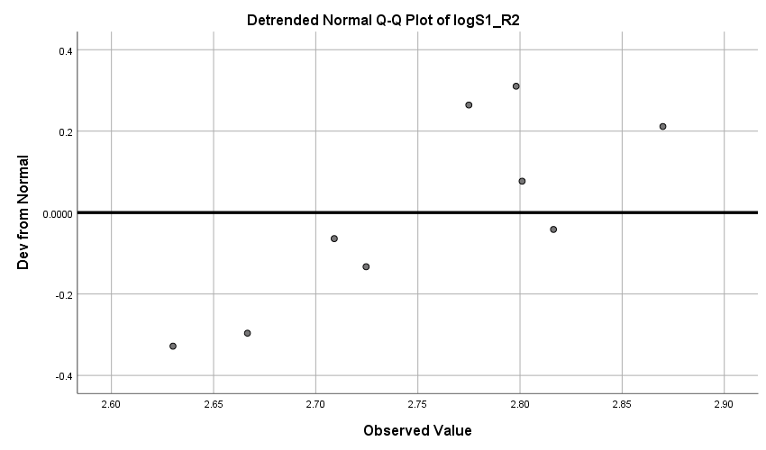

# **logS2_R1**

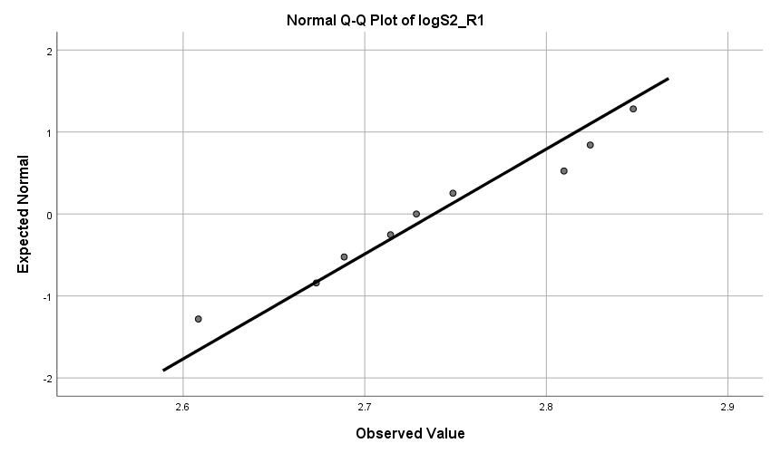

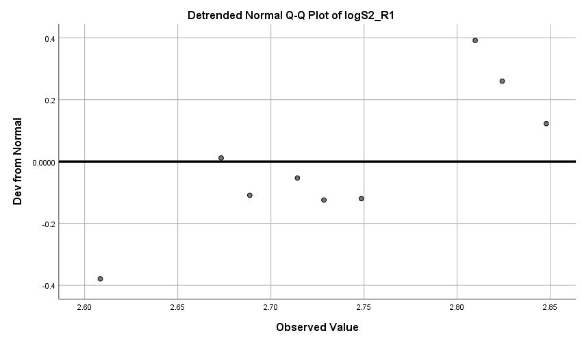

# **logS2_R2**

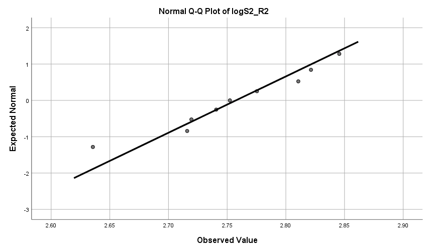

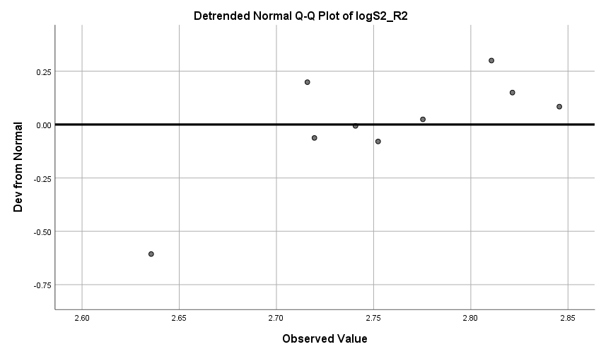

T-TEST PAIRS=logS1_R1 logS2_R1 logS1_R2 WITH logS1_R2 logS2_R2 logS2_R2 (PAIRED)  
/CRITERIA=CI(.9500)  
/MISSING=ANALYSIS.

# **T-Test**

NotesNotes, table, 0 levels of column headers and 2 levels of row headers, table with 3 columns and 14 rows

| Output Created |  | 16-APR-2019 00:48:27 |
| --- | --- | --- |
| Comments |  |  |
| Input | Data | Z:\Documents\GitHub\STISIM-Task-Analysis\SPSS Results\Saccade_peakV_30-40.sav |
|  | Active Dataset | DataSet3 |
|  | Filter | <none> |
|  | Weight | <none> |
|  | Split File | <none> |
|  | N of Rows in Working Data File | 13 |
| Missing Value Handling | Definition of Missing | User defined missing values are treated as missing. |
|  | Cases Used | Statistics for each analysis are based on the cases with no missing or out-of-range data for any variable in the analysis. |
| Syntax |  | T-TEST PAIRS=logS1_R1 logS2_R1 logS1_R2 WITH logS1_R2 logS2_R2 logS2_R2 (PAIRED) /CRITERIA=CI(.9500) /MISSING=ANALYSIS. |
| Resources | Processor Time | 00:00:00.00 |
|  | Elapsed Time | 00:00:00.00 |

Paired Samples StatisticsPaired Samples Statistics, table, 1 levels of column headers and 2 levels of row headers, table with 6 columns and 8 rows

|  |  | Mean | N | Std. Deviation | Std. Error Mean |
| --- | --- | --- | --- | --- | --- |
| Pair 1 | logS1_R1 | 2.7436 | 11 | .06057 | .01826 |
|  | logS1_R2 | 2.7639 | 11 | .07282 | .02196 |
| Pair 2 | logS2_R1 | 2.7323 | 11 | .07960 | .02400 |
|  | logS2_R2 | 2.7439 | 11 | .07399 | .02231 |
| Pair 3 | logS1_R2 | 2.7524 | 11 | .08697 | .02622 |
|  | logS2_R2 | 2.7439 | 11 | .07399 | .02231 |

Paired Samples CorrelationsPaired Samples Correlations, table, 1 levels of column headers and 2 levels of row headers, table with 5 columns and 5 rows

|  |  | N | Correlation | Sig. |
| --- | --- | --- | --- | --- |
| Pair 1 | logS1_R1 & logS1_R2 | 11 | .591 | .056 |
| Pair 2 | logS2_R1 & logS2_R2 | 11 | .796 | .003 |
| Pair 3 | logS1_R2 & logS2_R2 | 11 | .837 | .001 |

Paired Samples TestPaired Samples Test, table, 3 levels of column headers and 2 levels of row headers, table with 10 columns and 7 rows

[output not shown]

*Nonparametric Tests: Related Samples.  
NPAR TESTS  
/WILCOXON=logS1_R1 logS2_R1 logS1_R2 WITH logS1_R2 logS2_R2 logS2_R2 (PAIRED)  
/MISSING ANALYSIS.

# **NPar Tests**

NotesNotes, table, 0 levels of column headers and 2 levels of row headers, table with 3 columns and 16 rows

| Output Created |  | 16-APR-2019 00:48:27 |
| --- | --- | --- |
| Comments |  |  |
| Input | Data | Z:\Documents\GitHub\STISIM-Task-Analysis\SPSS Results\Saccade_peakV_30-40.sav |
|  | Active Dataset | DataSet3 |
|  | Filter | <none> |
|  | Weight | <none> |
|  | Split File | <none> |
|  | N of Rows in Working Data File | 13 |
| Missing Value Handling | Definition of Missing | User-defined missing values are treated as missing. |
|  | Cases Used | Statistics for each test are based on all cases with valid data for the variable(s) used in that test. |
| Syntax |  | NPAR TESTS /WILCOXON=logS1_R1 logS2_R1 logS1_R2 WITH logS1_R2 logS2_R2 logS2_R2 (PAIRED) /MISSING ANALYSIS. |
| Resources | Processor Time | 00:00:00.00 |
|  | Elapsed Time | 00:00:00.00 |
|  | Number of Cases Allowed<sup>a</sup> | 349525 |

a. Based on availability of workspace memory.

# **Wilcoxon Signed Ranks Test**

RanksRanks, table, 1 levels of column headers and 2 levels of row headers, table with 5 columns and 23 rows

|  |  | N | Mean Rank | Sum of Ranks |
| --- | --- | --- | --- | --- |
| logS1_R2 - logS1_R1 | Negative Ranks | 3<sup>a</sup> | 5.67 | 17.00 |
|  | Positive Ranks | 8<sup>b</sup> | 6.13 | 49.00 |
|  | Ties | 0<sup>c</sup> |  |  |
|  | Total | 11 |  |  |
| logS2_R2 - logS2_R1 | Negative Ranks | 5<sup>d</sup> | 5.40 | 27.00 |
|  | Positive Ranks | 6<sup>e</sup> | 6.50 | 39.00 |
|  | Ties | 0<sup>f</sup> |  |  |
|  | Total | 11 |  |  |
| logS2_R2 - logS1_R2 | Negative Ranks | 6<sup>g</sup> | 6.67 | 40.00 |
|  | Positive Ranks | 5<sup>h</sup> | 5.20 | 26.00 |
|  | Ties | 0<sup>i</sup> |  |  |
|  | Total | 11 |  |  |

a. logS1_R2 < logS1_R1  
b. logS1_R2 > logS1_R1  
c. logS1_R2 = logS1_R1  
d. logS2_R2 < logS2_R1  
e. logS2_R2 > logS2_R1  
f. logS2_R2 = logS2_R1  
g. logS2_R2 < logS1_R2  
h. logS2_R2 > logS1_R2  
i. logS2_R2 = logS1_R2

Test Statistics<sup>a</sup>Test Statistics, table, 1 levels of column headers and 1 levels of row headers, table with 4 columns and 7 rows

|  | logS1_R2 - logS1_R1 | logS2_R2 - logS2_R1 | logS2_R2 - logS1_R2 |
| --- | --- | --- | --- |
| Z | -1.423<sup>b</sup> | -.533<sup>b</sup> | -.622<sup>c</sup> |
| Asymp. Sig. (2-tailed) | .155 | .594 | .534 |

a. Wilcoxon Signed Ranks Test  
b. Based on negative ranks.  
c. Based on positive ranks.